# Problem Set 2

Jacob Farmer

Due September 16, 2026

First, download accident2019 from Canvas and save it in the same folder that you have this homework (preferrably your class folder that we made on your desktop). This is data from the 2019 Fatal Accident Reporting System (FARS) from the National Highway Traffic Safety Administration. It includes information from every single fatal car accident that occurred in the United States in 2019.

```r
accident2019 <- read_csv("~/ECO 411/data/accident2019.CSV") %>%
  select(STATE,STATENAME,PEDS,PERSONS,COUNTY,COUNTYNAME,DAY,MONTH,DAY_WEEKNAME,HOUR,MINUTE,ROUTENAME,RUR_URBNAME,WEATHER1NAME,LGT_CONDNAME,FATALS,DRUNK_DR)
```

Use the “Coding in R” and “Data Visualizations” slides as a resource to complete the following tasks.

Write some code to show which day of the week had the most fatal accidents in 2019

```r
table(accident2019$DAY_WEEKNAME)
```

```
##
##    Friday    Monday  Saturday    Sunday  Thursday   Tuesday Wednesday
##      5293      4375      5646      5128      4468      4315      4262
```

```r
# Saturday had the most fatal accidents in 2019.
```

Create a continuous variable from 0-24 that tells precisely how many hours after midnight a crash occurred. Call it hrs_after_midnight. For example, a crash that occurred at 6:30AM should have a value of hrs_after_midnight of 6.5.

```r
accident2019 <- accident2019 |>
  mutate(hrs_after_midnight = HOUR + MINUTE/60)
head(accident2019$hrs_after_midnight)
```

```
## [1] 12.900000 18.050000 19.000000  3.250000  5.833333 12.500000
```

Now create a histogram for the new variable

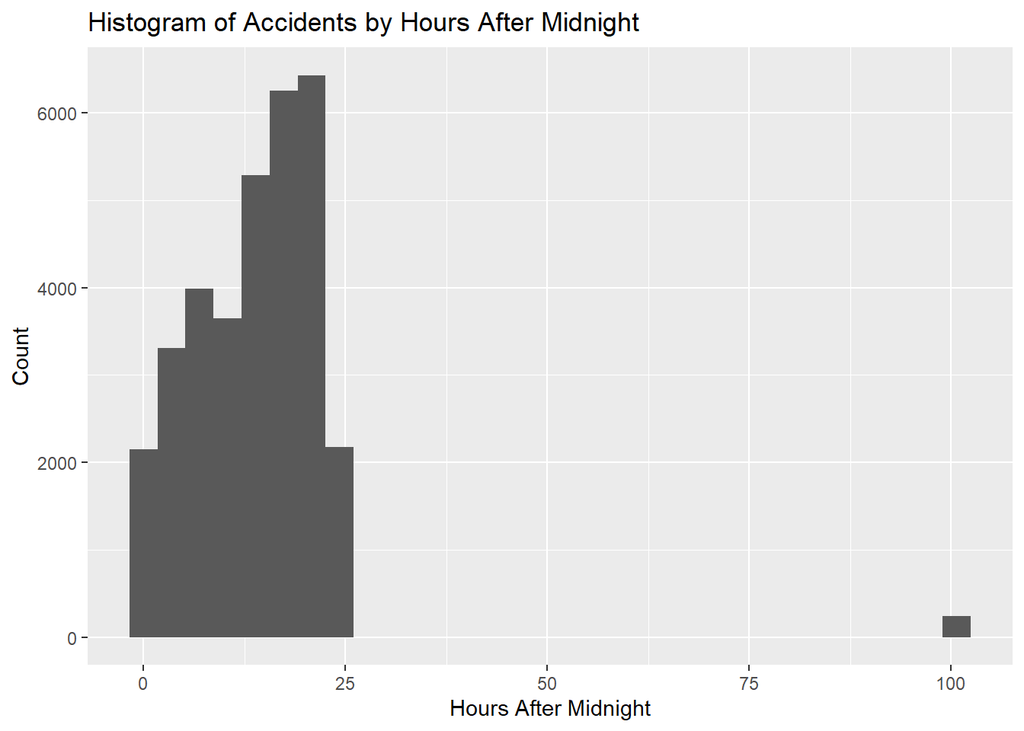

```r
ggplot(accident2019, aes(x = hrs_after_midnight)) +
  geom_histogram() +
  labs(
    title = "Histogram of Accidents by Hours After Midnight",
    x = "Hours After Midnight",
    y = "Count"
  )
```

Does anything look off about this?

*The current histogram has data points that chart accidents about 100 hours after midnight, which is not possible given time constraints.*

To dig into this, make a frequency table of all the values of the HOUR variable using the table() command

```r
table(accident2019$HOUR)
```

```
##
##    0    1    2    3    4    5    6    7    8    9   10   11   12   13   14   15
## 1231 1209 1148  874  788 1102 1267 1185  920  915 1036 1203 1333 1425 1580 1775
##   16   17   18   19   20   21   22   23   99
## 1721 1763 1927 1832 1921 1950 1624 1514  244
```

The 99s mean the variable is missing, so write some code that drops the observations with a value of 99 and then make the graph again.

```r
accident2019 <- accident2019 |>
  mutate(HOUR = ifelse(HOUR > 23, NA, HOUR),
         MINUTE = ifelse(MINUTE > 59, NA, MINUTE),
         hrs_after_midnight = HOUR + MINUTE/60
  )
```

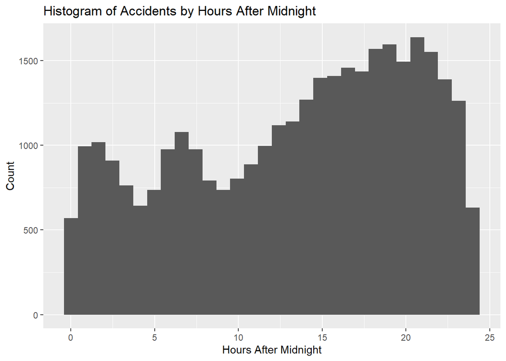

```r
ggplot(accident2019, aes(x = hrs_after_midnight)) +
  geom_histogram() +
  labs(
    title = "Histogram of Accidents by Hours After Midnight",
    x = "Hours After Midnight",
    y = "Count"
  )
```

Does anything stand out to you about this?

*It seems that most accidents occur between 10 and 23 hours after midnight, making the histogram slightly left skewed.*

Make a summary stats table for the variables PERSONS, PEDS, FATALS, and DRUNK_DR. Show the N, Mean, Standard Deviation, Min, and Max.

```r
sumtable(accident2019,
         vars = c("PERSONS", "PEDS", "FATALS", "DRUNK_DR"),
         summ = c('n(x)','mean(x)','sd(x)','min(x)','max(x)'),
         summ.names = c('N','Mean','SD','Min','Max')
        )
```

Summary Statistics

[output not shown]

I want to know what weather condition leads to the deadliest crashes. Use the summarise() function to display the mean and total FATALS for each value of WEATHER1COND

```r
accident2019 |>
  group_by(WEATHER1NAME) |>
  summarize(mean_deaths = mean(FATALS), total_deaths = sum(FATALS))
```

```
## # A tibble: 13 × 3
##    WEATHER1NAME             mean_deaths total_deaths
##    <chr>                          <dbl>        <dbl>
##  1 Blowing Sand, Soil, Dirt        1.22           11
##  2 Blowing Snow                    1.05           23
##  3 Clear                           1.09        24612
##  4 Cloudy                          1.09         5415
##  5 Fog, Smog, Smoke                1.10          375
##  6 Freezing Rain or Drizzle        1.09           36
##  7 Not Reported                    1.08         2510
##  8 Other                           1              27
##  9 Rain                            1.09         2740
## 10 Reported as Unknown             1.04          174
## 11 Severe Crosswinds               1.04           50
## 12 Sleet or Hail                   1.03           40
## 13 Snow                            1.11          342
```

Why do you think “clear” has the most deaths? Does that seem counter intuitive?

*It would make sense for days with severe weather to have more total deaths and more deaths on average if those days with severe weather had more crashes than clear days. Perhaps most days are clear so naturally more crashes occur on clear days which leads to more deaths. Another hypothesis is that drivers are more careful on days with severe weather and less careful on clear days, leading to more deaths.*

OK, let’s make a map!

First, we need a fips variable with the combined 5-digit state and county fips code. Create a variable called “fips” which combines STATE (two-digit state code) with COUNTY (the three-digit county code) into the five digit county fips code. For example, Ohio is state fips code 39, Butler County is county fips code 17. Together, the fips code for Butler County, OH, should be 39017.

```r
accident2019 <- accident2019 |>
  mutate(fips=(STATE*1000)+COUNTY)
```

I want to make a map with the log of the total number of fatalities from traffic accidents for each county. First, create a new dataset that calculates this variable from the original dataset. (Hint: you will again use group_by() and summarise())

```r
accident_map <- accident2019 |>
  group_by(fips, STATE, COUNTY) |>
  summarize(total_fatalities = sum(FATALS), .groups = "drop") |>
  mutate(log_fatalities = log(total_fatalities))
```

Now make a map that plots this variable

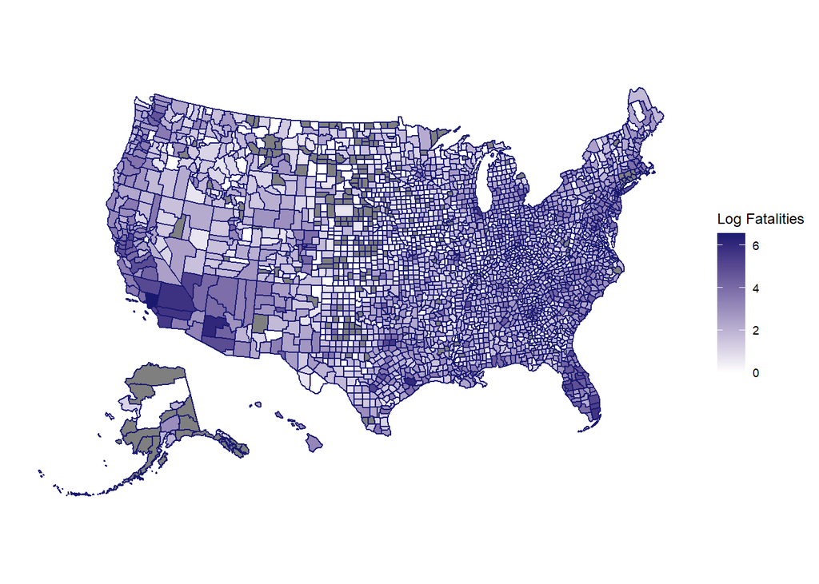

```r
library(usmap)
plot_usmap(data = accident_map, values = "log_fatalities", color = "midnightblue") +
  scale_fill_continuous( low = "white", high = "midnightblue",
                         name = "Log Fatalities", label = scales::comma) +
  theme(legend.position = "right")
```

**Why are some counties plotted gray?**

*Some counties are plotted gray because there is no available data for those counties, or there were no fatalities in those counties in 2019.*